# Data Visualization Techniques

Venustiano Soancatl Aguilar

## Content

- **Preprocessing**
  - Table formats
  - Normalization
- **Visualization techniques**
  - Distributions
    - Histograms
    - Violing plots
    - Box plots
- **Preparing for publication**

## Wide format

- Wide format: each subject/measure is its own column. Good for human-readable reports and some modeling functions.

Example (wide):

Wide format

Each repeated measure has its own column

| id | math | english |
| --- | --- | --- |
| 1 | 90 | 80 |
| 2 | 85 | 88 |

## Long format

- Long (tidy) format: one observation per row, each variable is a column (key-value pair for repeated measures). Preferred for tidy data workflows (dplyr/tidyr, pandas melt).

Long (tidy) format

One observation per row (id + subject -> score)

| id | subject | score |
| --- | --- | --- |
| 1 | math | 90 |
| 2 | math | 85 |
| 1 | english | 80 |
| 2 | english | 88 |

## Exergame dataset <sup>1</sup>

First 10 rows of ../../data/exergamewf.csv (400x16), 40 participants

| iSubj | trial | Age | Decade | medLrms51 | medTI51 | medK | meanK | medSpeed | medTIms51 | medLcovD51 | medLsd51 | medLcov51 | medLrmslD51 | medLsdD51 | older |
| --- | --- | --- | --- | --- | --- | --- | --- | --- | --- | --- | --- | --- | --- | --- | --- |
| 1 | 1 | 76 | 7 | 0.1894931 | 0.5895294 | 207.8009 | 333.8615 | 0.4887213 | 0.8063448 | 0.7447658 | 0.02060208 | 0.10868742 | 1.2591721 | 0.12906757 | TRUE |
| 1 | 2 | 76 | 7 | 0.2041523 | 0.6973378 | 223.2943 | 319.6015 | 0.5182781 | 0.7754507 | 0.5069439 | 0.01644558 | 0.07814028 | 1.2633661 | 0.10590245 | TRUE |
| 1 | 3 | 76 | 7 | 0.2173473 | 0.7861308 | 136.4008 | 272.4609 | 0.5841934 | 0.5119019 | 0.7061267 | 0.04737236 | 0.23646721 | 0.7827964 | 0.13391692 | TRUE |
| 1 | 4 | 76 | 7 | 0.1695694 | 1.0206954 | 162.0346 | 289.9279 | 0.5901514 | 0.4163981 | 0.7018032 | 0.03901695 | 0.26536092 | 0.4875698 | 0.10863750 | TRUE |
| 1 | 5 | 76 | 7 | 0.1707855 | 0.7697467 | 141.7677 | 300.6258 | 0.5517064 | 0.5500293 | 0.7531606 | 0.03679774 | 0.23590743 | 0.6461938 | 0.11960964 | TRUE |
| 1 | 6 | 76 | 7 | 0.1897457 | 0.8447487 | 135.1824 | 278.8230 | 0.5872821 | 0.4505710 | 0.6610873 | 0.04081446 | 0.24733843 | 0.5800137 | 0.11645546 | TRUE |
| 1 | 7 | 76 | 7 | 0.2233555 | 0.7575400 | 194.8239 | 300.0683 | 0.5530803 | 0.7030368 | 0.3478552 | 0.01441217 | 0.06038580 | 1.1837717 | 0.08177191 | TRUE |
| 1 | 8 | 76 | 7 | 0.2409097 | 0.7414884 | 226.1782 | 324.9164 | 0.5225434 | 0.7732494 | 0.2648009 | 0.01068888 | 0.04361652 | 1.4287875 | 0.06494999 | TRUE |
| 1 | 9 | 76 | 7 | 0.2347833 | 0.6954884 | 201.0556 | 300.1745 | 0.5300633 | 0.7637143 | 0.3943936 | 0.01528410 | 0.06477809 | 1.3693579 | 0.09403986 | TRUE |
| 1 | 10 | 76 | 7 | 0.2138546 | 0.6711597 | 203.4890 | 298.0097 | 0.5402634 | 0.7405751 | 0.4288368 | 0.01493881 | 0.06972877 | 1.2463371 | 0.09307257 | TRUE |

[^1]: [Visual Data Exploration for Balance Quantification in Real-Time During Exergaming](https://journals.plos.org/plosone/article?id=10.1371/journal.pone.0170906)

## `exergamewt.csv` into long format

Using AI:

1. Launch [mybinder](https://mybinder.org/v2/gh/Venustiano/DataVis2/HEAD?urlpath=lab)
2. Go to the `./material/data` folder and create a new `python/R` notebook
3. Use the `sparkle icon` on cell toolbar to show the inline chat popover.
4. Use the following prompts to generate the required code:
   1. Write `python` and `R` code to see the columns of the exergamewf.csv file.
   2. Convert the `<exergamewf_data>` into a `data.table` and create a long format table using the ‘iSubj’, ‘trial’, ‘Age’, ‘Decade’ and ‘older’ columns as keys.
   3. Plot a histogram in ggplot of the ‘value’ column of the `<exergamewf_long>` table.

## Histogram

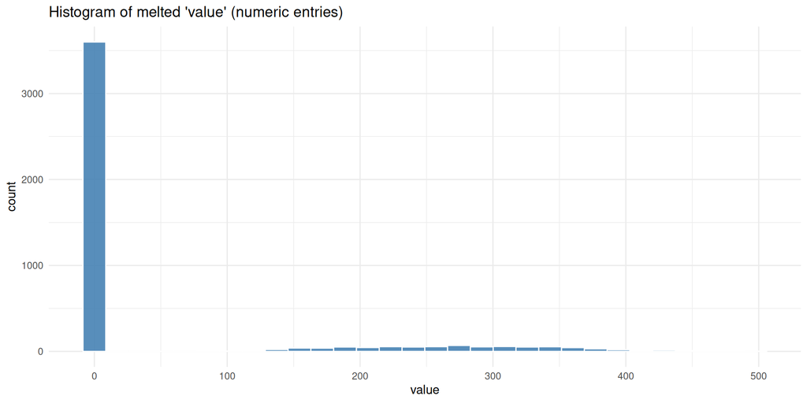

## Normalization

Standard score:

$$x' = \frac{x-\mu}{\sigma}$$

Min-Max Feature scaling:

$$x' = \frac{x-min(x)}{max(x)-min(x)}$$

## After `min max` normalization

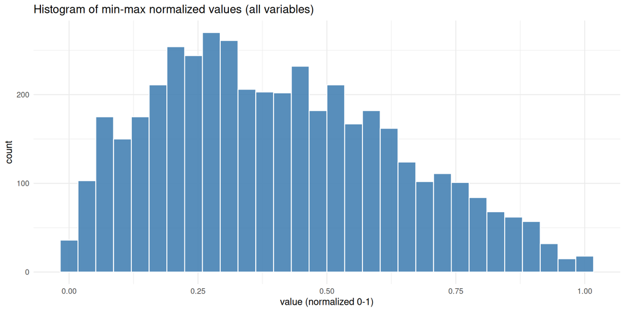

## Adding a distribution curve

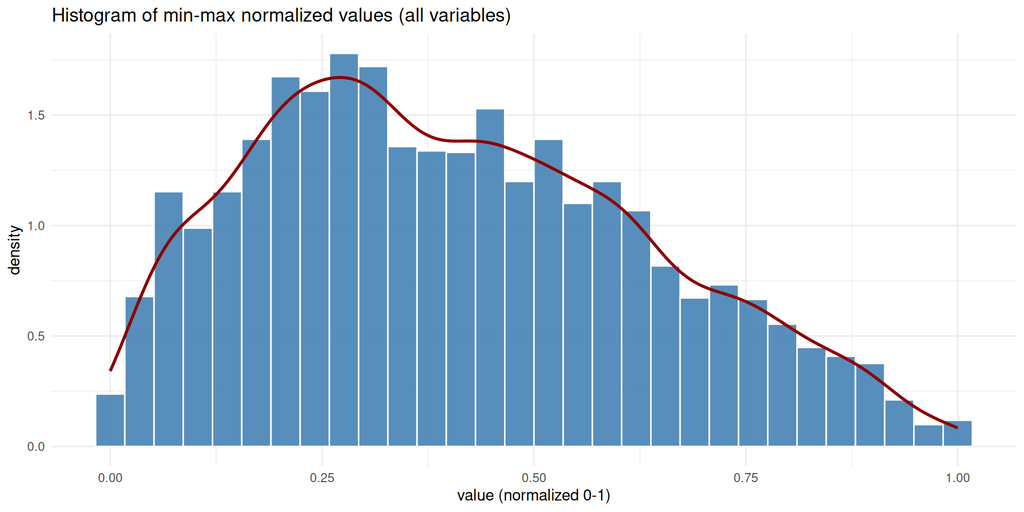

## Overlapping distributions<sup>1</sup>

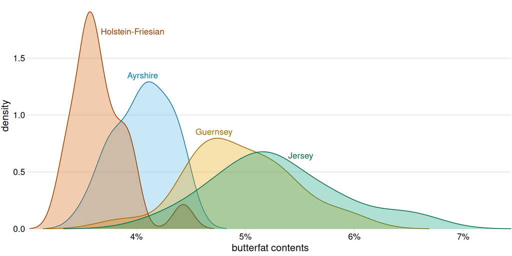

[^2]: [Source: FDV Histograms-densityplots, `(Fig7_11.. .ipynb)`](https://clauswilke.com/dataviz/histograms-density-plots.html#multiple-histograms-densities)

## Ridgeline plot<sup>1</sup>

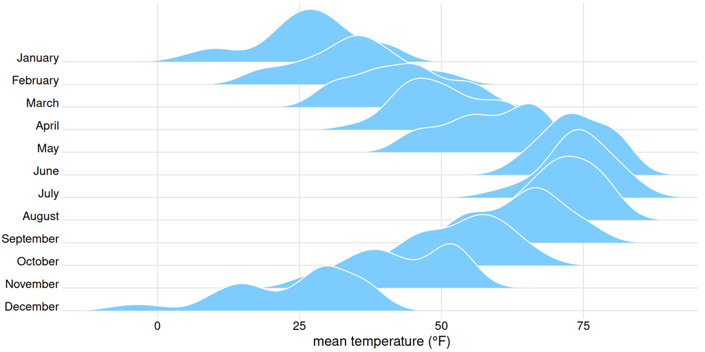

[^3]: [Source: FDV Visualizing many distributions at once `(Fig9_9... .ipynb)`](https://clauswilke.com/dataviz/boxplots-violins.html#boxplots-violins-horizontal)

## Meet the violin plot

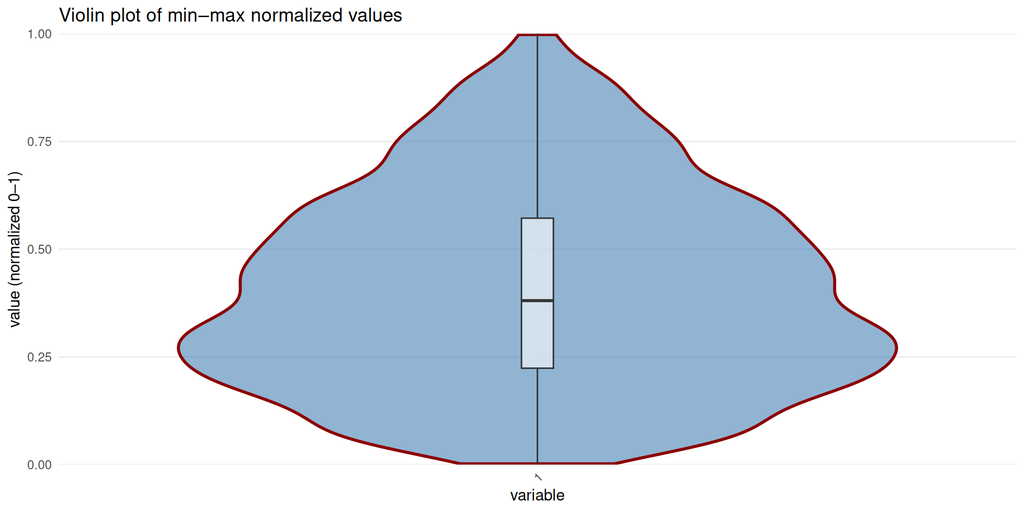

## A practical example

Loading the data:

[output not shown]

```python
# Importing the packages
import pandas as pd
# Loading and displaying the data
lf = pd.read_csv('../../data/exergamelf2.csv')
lf.head()
```

```
   idrow  Age  Decade  iSubj  trial     myVars     value   normVal  older
0      0   20       2     21      1  medLrms51  0.294961  0.879737  False
1      1   20       2     21      2  medLrms51  0.308855  0.926365  False
2      2   20       2     21      3  medLrms51  0.285579  0.848253  False
3      3   20       2     21      4  medLrms51  0.264111  0.776211  False
4      4   20       2     21      5  medLrms51  0.308285  0.924452  False
```

## Creating violin plots

```python
import plotly.express as px

plot = px.violin(x=lf['myVars'],
                 y=lf['normVal']
  )

plot.show()
```

[interactive chart not shown]

## Overlapping violin plots

```python
plot = px.violin(x=lf['myVars'],
                 y=lf['normVal'],
                 color = lf["older"]
                )

# make violins overlap and improve visibility
plot.update_traces(opacity=0.6,
                   width=0.8
                  )             # semi-transparent + narrower violins

plot.update_layout(violinmode='overlay')  # overlay (instead of side-by-side)

# optional: rotate x labels if long category names
plot.update_layout(xaxis_tickangle=45)

plot.show()
```

## Overlapping violin plots

[interactive chart not shown]

## Preparing for publication

- Remove unnecessary elements
  - Color background
  - Axis title
- Select appropriate visual variables
  - color
- Add appropriate labels
- Save a high resolution image
- Avoid chart junk

## Colors

colorbrewer2.org

## High quality plots with LaTex

- [tikz](http://www.texample.net/tikz/examples/all/?page=17)
- tikzDevice (only in R)

  `scripts/FDV/Fig2_3_temperature_plot_tikz.ipynb`
- Useful for publications
- Match plot and main text fonts
- Can include complex mathematical formulae
- `tikzDevice` works with r magic in jupyter notebooks

## The ggplot version

```r
p <- ggplot(long_dt,
            aes(x = variable,
                y = value_norm,
                fill = factor(older)
              )
            ) +
  geom_violin(position = position_identity(),   # overlay violins at same x
              alpha = 0.5,
              width = 0.8,
              trim = FALSE,
              color = NA
              ) +
  labs(title = "Overlapping violins of per-variable normalized values",
       x = "variable",
       y = "value (normalized 0-1)",
       fill = "older",
       color = "older") +
  theme_minimal() +
  theme(axis.text.x = element_text(angle = 45, hjust = 1))
```

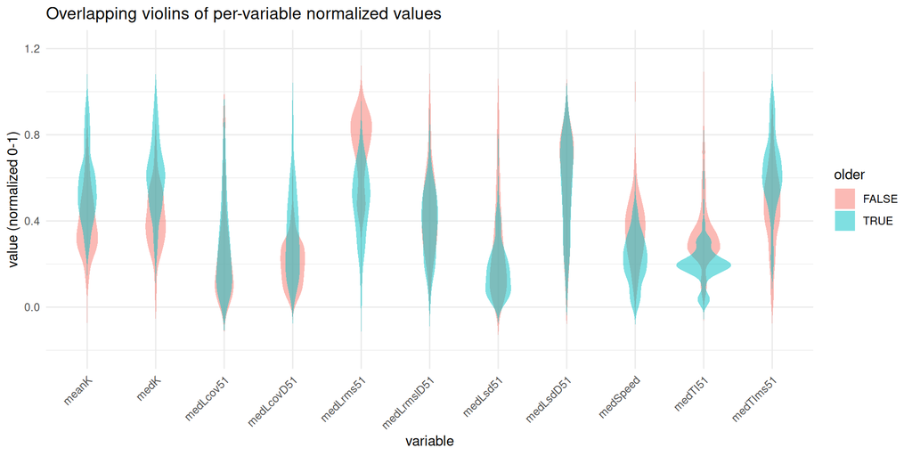

## ggplot -> LaTeX

```r
library(tikzDevice)   # assume installed

# 1) Write a standalone .tex that contains the TikZ picture
tikz("p_plot.tex",
  width = 6,
  height = 4,
  standAlone = TRUE
)

  print(p)   # print the ggplot object to the tikz device

dev.off()
```

```r
# 2) Compile to PDF (requires a LaTeX engine available)

tools::texi2dvi("p_plot.tex", pdf = TRUE, clean = TRUE)
```

## TikzDevice result

[figure not shown]

## Published result<sup>1</sup>

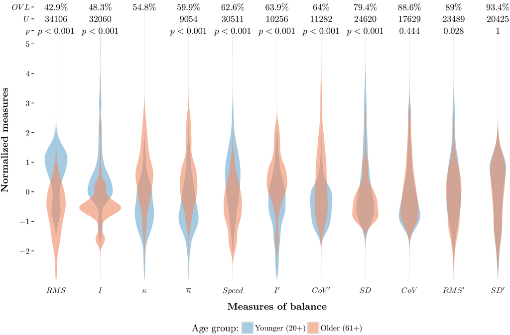

[^4]: Source: 10.1371/journal.pone.0170906.g006

## Boxplots

```python
plot = px.box(x=lf['myVars'],
              y=lf['normVal'],
              color = lf["older"]
            )
```

- Median
- Quartiles 25% above and below the median
- Whiskers
- Outliers

[interactive chart not shown]

## Would it be better to use boxplots?

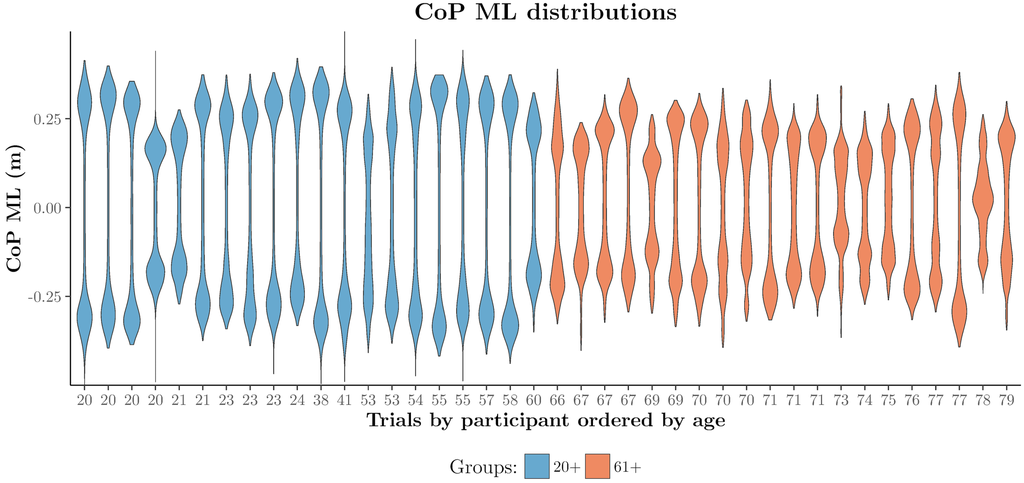

Source: https://doi.org/10.1371/journal.pone.0170906.g004